# Het rescorla Wagner model

### Micha de Groot (10434410) en Roand de Jong (10791930)

Het Rescorla Wagner model kan gebruikt worden om de associatieve sterkte van een geconditioneerde stimulus te modelleren. In het onderstaande voorbeeld wordt dit weergegeven voor een aantal experimenten.

Het model heeft een aantal parameters die aangepast kunnen worden om verschillende experimenten en gevallen te modelleren. De associatie sterkte van de geconditioneerde stimulus verandert per leer-trial, afhankelijk van de parameters. Dit wordt berekend met de formules:
$$V_t = V_{t-1} + \Delta V_t$$
$$\Delta V_t = \alpha \beta (V_{max} - V_{t-1})$$

De eerste parameter is alfa. Alfa is een waarde tussen 0 en 1, die de sterkte van de stimulus die geconditioneerd wordt weergeeft. De tweede parameter, beta, zit ook tussen 0 en 1 en representeert de sterkte van de ongeconditioneerde stimulus. De maximale associatieve sterkte is V_max, die in principe elke waarde kan hebben en geen eenheid heeft. De associatiesterkte kan ook vóór de leer-trials al bestaan en kan worden meegegeven in de parameter V_start.

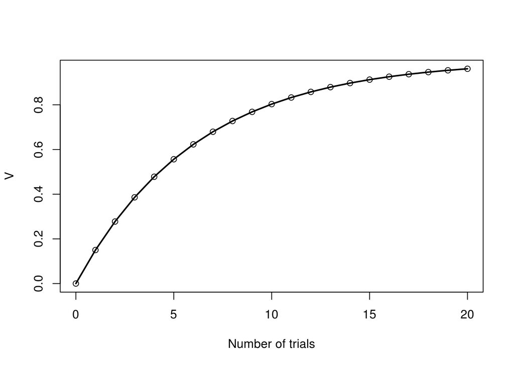

```r
rescorla <- function(v_start, v_max, alpha, num_trials)
{
  v_vec = c(v_start)
  delta_v_vec = c(0)

  for(i in 2:(num_trials+1))
  {
    delta_v_vec[i] = alpha*(v_max - v_vec[i-1])
    v_vec[i] = v_vec[i-1] + delta_v_vec[i]
  }

  data<-as.data.frame(cbind(v_vec, delta_v_vec))
  colnames(data)<-c("v","delta_v")
  return(data)
}

num_trials = 20
data = rescorla(0, 1, 0.15, num_trials)
plot(seq(from=0, to=num_trials), data$v, xlab = "Number of trials", ylab = "V")
lines(seq(from=0, to=num_trials), data$v,col="black",lwd=2)
```

# De betekenis van de parameters

De alfa parameter Zoals hieronder uitgebeeld is, wordt het maximum sneller berijkt als de parameter alfa groter is. Dit zorgt er voor dat de verandering van V sneller nul benadert.

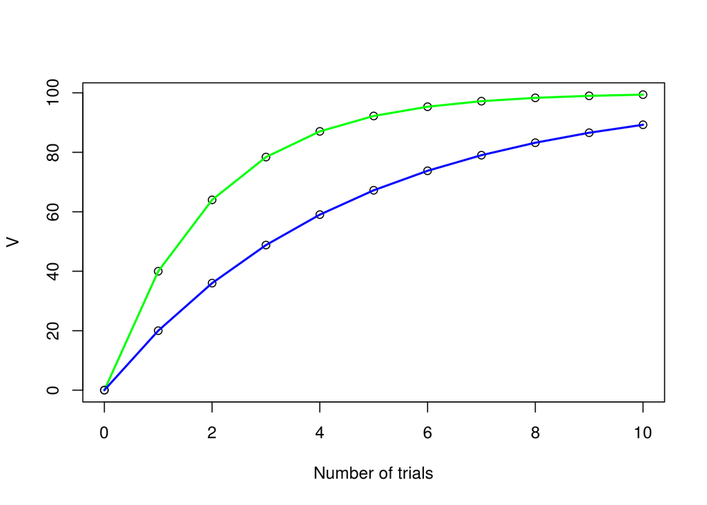

```r
v_start    = 0
v_max      = 100
alpha     = 0.4
num_trials = 10

data1 = rescorla(v_start, v_max, alpha, num_trials)

alpha = 0.2
data2 = rescorla(v_start, v_max, alpha, num_trials)

plot(seq(v_start, num_trials), data1$v, xlab = "Number of trials", ylab = "V")
lines(seq(from=v_start, to=num_trials), data1$v,col="green",lwd=2)
points(seq(from=v_start, to=num_trials), data2$v,col="black")
lines(seq(from=v_start, to=num_trials), data2$v,col="blue",lwd=2)
```

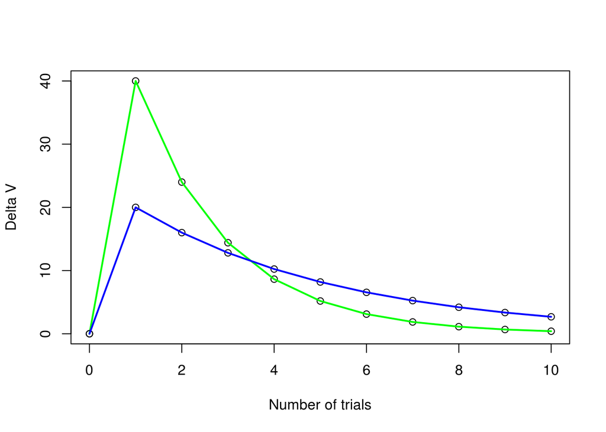

```r
plot(seq(v_start, num_trials), data1$delta_v, xlab = "Number of trials", ylab = "Delta V")
lines(seq(from=v_start, to=num_trials), data1$delta_v,col="green",lwd=2)
points(seq(from=v_start, to=num_trials), data2$delta_v,col="black")
lines(seq(from=v_start, to=num_trials), data2$delta_v,col="blue",lwd=2)
```

# Extincie curve

```r
V_start = data$v[10]
V_max = 0
alpha = 0.4
num_trials = 11

data_extinction = rescorla(V_start, V_max, alpha, num_trials)
data_extinction
```

```
##              v      delta_v
## 1  0.768383054  0.000000000
## 2  0.461029832 -0.307353221
## 3  0.276617899 -0.184411933
## 4  0.165970740 -0.110647160
## 5  0.099582444 -0.066388296
## 6  0.059749466 -0.039832978
## 7  0.035849680 -0.023899787
## 8  0.021509808 -0.014339872
## 9  0.012905885 -0.008603923
## 10 0.007743531 -0.005162354
## 11 0.004646118 -0.003097412
## 12 0.002787671 -0.001858447
```

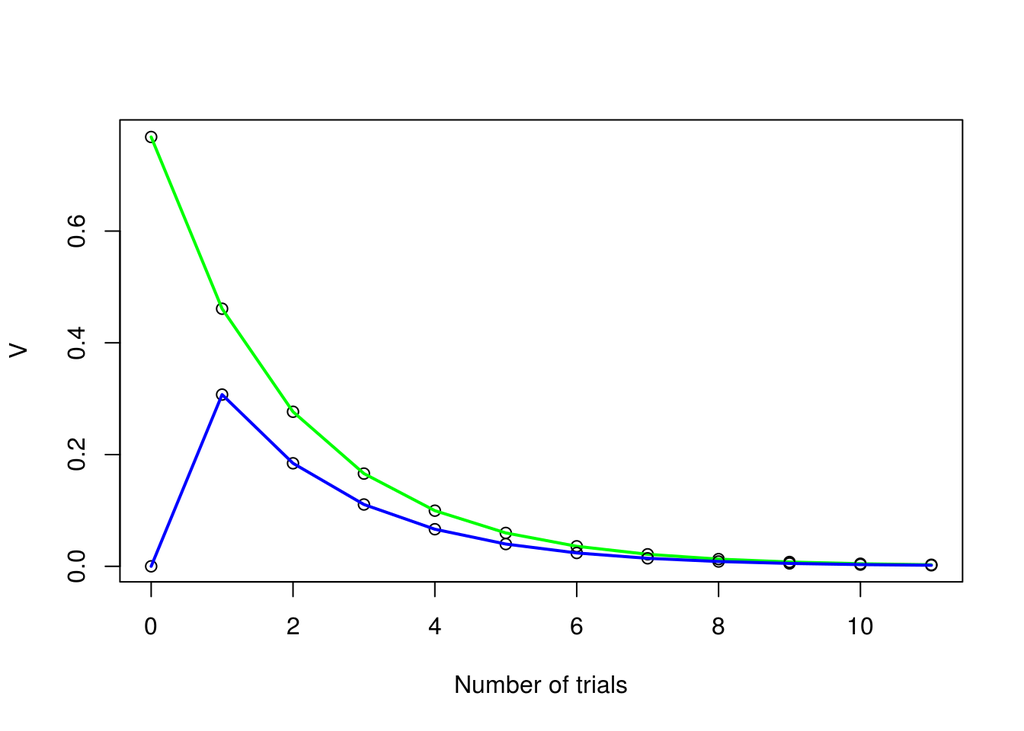

```r
plot(seq(from=v_start, to=num_trials), data_extinction$v, xlab = "Number of trials", ylab = "V")
lines(seq(from=v_start, to=num_trials), data_extinction$v,col="green",lwd=2)
points(seq(from=v_start, to=num_trials), abs(data_extinction$delta_v))
lines(seq(from=v_start, to=num_trials), abs(data_extinction$delta_v),col="blue",lwd=2)
```

# Compound Stimuli

Bij compound stimuli wordt het leerproces beïnvloed door een samenstelling van meerdere stimuli. Deze stimuli kunnen ook een andere leersnelheid hebben. In de onderstaande grafieken is te zien hoe een leerproces sneller gaat als meerdere stimulie het proces beïnvloeden, en hoe de verandering in acquisitie verandert. De compound stimuli worden uitgerekend met de volgende formules
$$V_{ab} = V_a + V_b$$
$$\Delta V_a = \alpha_a (V_{max} - V_{ab-1})\\
\Delta V_b = \alpha_b (V_{max} - V_{ab-1})$$

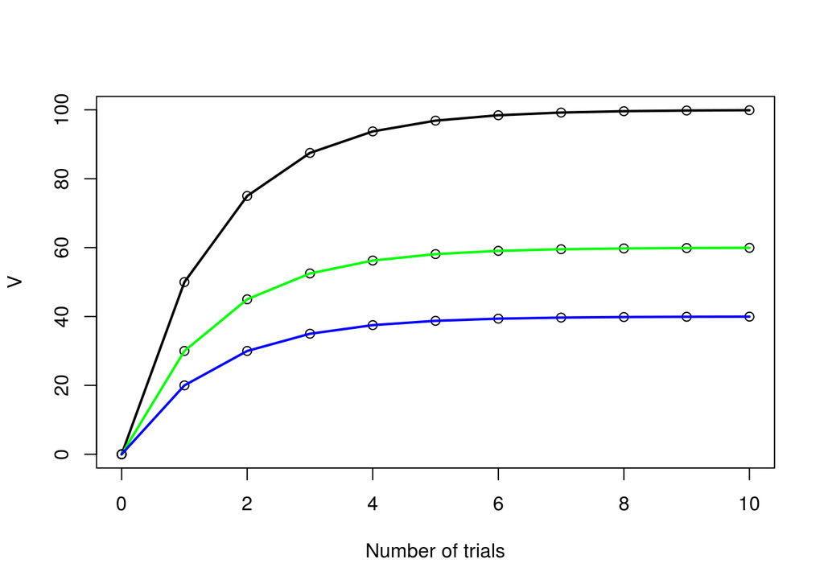

```r
rescorla_compound <- function(v_start, v_max, alpha1, alpha2, num_trials)
{
  v_vec1 = c(v_start)
  v_vec2 = c(v_start)
  v_vec_comp = c(v_start)
  delta_v_vec1 = c(0)
  delta_v_vec2 = c(0)

  for(i in 2:(num_trials+1))
  {
    delta_v_vec1[i] = alpha1*(v_max - v_vec_comp[i-1])
    delta_v_vec2[i] = alpha2*(v_max - v_vec_comp[i-1])
    v_vec1[i] = v_vec1[i-1] + delta_v_vec1[i]
    v_vec2[i] = v_vec2[i-1] + delta_v_vec2[i]
    v_vec_comp[i] = v_vec1[i] + v_vec2[i]
  }

  data<-as.data.frame(cbind(v_vec1, v_vec2, v_vec_comp, delta_v_vec1, delta_v_vec2))
  colnames(data)<-c("v1", "v2", "v_comp","delta_v1", "delta_v2")
  return(data)
}
v_start    = 0
v_max      = 100
alpha1     = 0.2
alpha2     = 0.3
num_trials = 10

data1 = rescorla_compound(v_start, v_max, alpha1, alpha2, num_trials)
plot(seq(v_start, num_trials), data1$v_comp, xlab = "Number of trials", ylab = "V")
lines(seq(from=v_start, to=num_trials), data1$v_comp,col="black",lwd=2)
points(seq(from=v_start, to=num_trials), data1$v2,col="black")
lines(seq(from=v_start, to=num_trials), data1$v2,col="green",lwd=2)
points(seq(from=v_start, to=num_trials), data1$v1,col="black")
lines(seq(from=v_start, to=num_trials), data1$v1,col="blue",lwd=2)
```

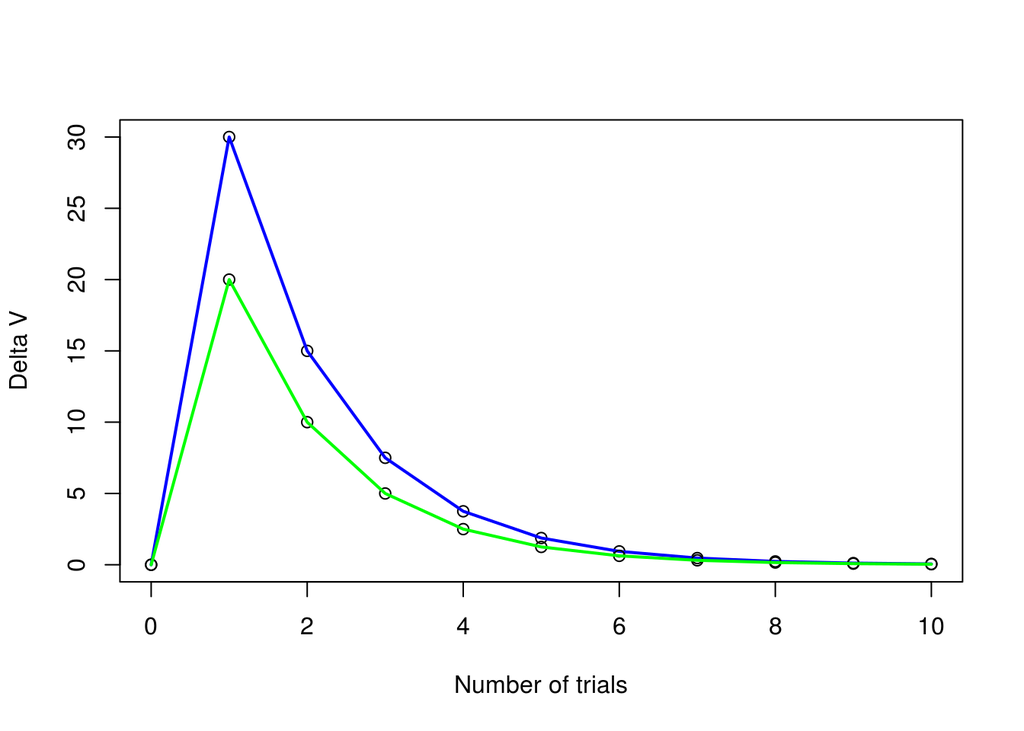

```r
plot(seq(v_start, num_trials), data1$delta_v2, xlab = "Number of trials", ylab = "Delta V")
lines(seq(from=v_start, to=num_trials), data1$delta_v2,col="blue",lwd=2)
points(seq(from=v_start, to=num_trials), data1$delta_v1,col="black")
lines(seq(from=v_start, to=num_trials), data1$delta_v1,col="green",lwd=2)
```

# Blocking

Bij blocking wordt het associeren van een CS_1 met een US geblokkeerd doordat tijdens de trials met CS_1 en de US ook een andere CS_2 getoond wordt. Deze CS_2 is al eerder geassocieerd met de US.

Doordat er dus al een associatie is tussen CS_2 en US wordt er niet een associatie aangeleerd tussen CS_1 en US.

In de eerste grafiek is te zien dat de ene CS op de normale manier geassocieerd wordt. In de tweede grafiek is te zien dat de tweede stimulus erg weinig geassocieerd wordt doordat de eerste CS al geassocieerd is.

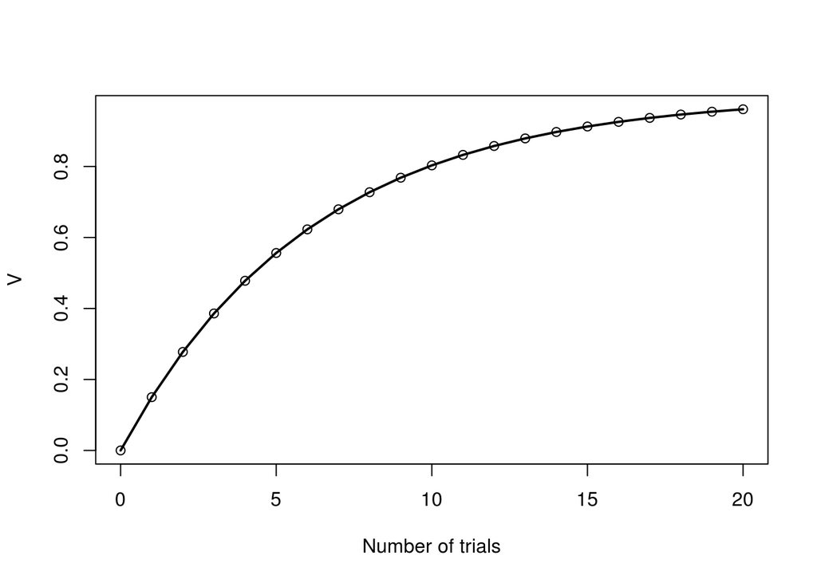

```r
# train CS_1 met US
v_start = 0
v_max = 1.0
num_trials = 20
alpha1 = 0.15
data_blocking = rescorla(v_start, v_max, alpha1, num_trials)

# trials met CS_1 en CS_2 tegelijk: dwz met compound stimuli
alpha2 = 0.15
v_start_second = data_blocking$v[num_trials+1]
data_blocking_second = rescorla_compound(v_start, v_max - v_start_second, alpha1, alpha2, num_trials)


plot(seq(from=0, to=num_trials), data_blocking$v, xlab = "Number of trials", ylab = "V")
lines(seq(from=0, to=num_trials), data_blocking$v,col="black",lwd=2)
```

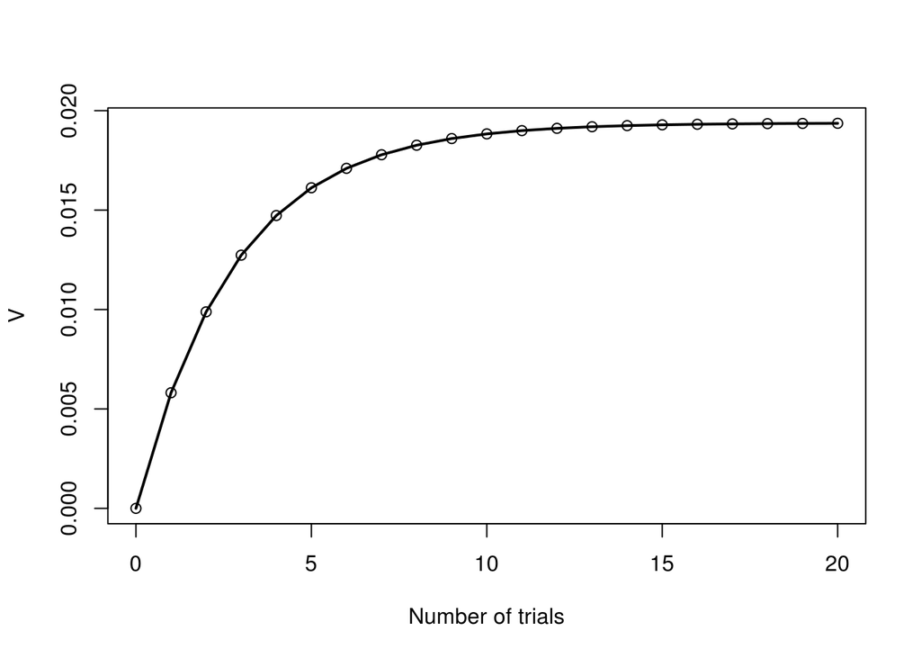

```r
plot(seq(from=0, to=num_trials), data_blocking_second$v2, xlab = "Number of trials", ylab = "V")
lines(seq(from=0, to=num_trials), data_blocking_second$v2,col="black",lwd=2)
```

# Bonus

Bij latent inhibition wordt er minder snel een associatie gemaakt tussen de CS en de US doordat de CS eerst voor een aantal trials zonder de US wordt gepresenteerd. Hierdoor gaat de alfawaarde van de CS omlaag. Als dan daarna wel de Us met de CS wordt getood wordt de associatie langzamer geleerd. In de grafiek is te zien dat de groep die eerst de CS gepresenteerd kreeg zonder de US daarna langzamer de CS en de US met elkaar associeerde.

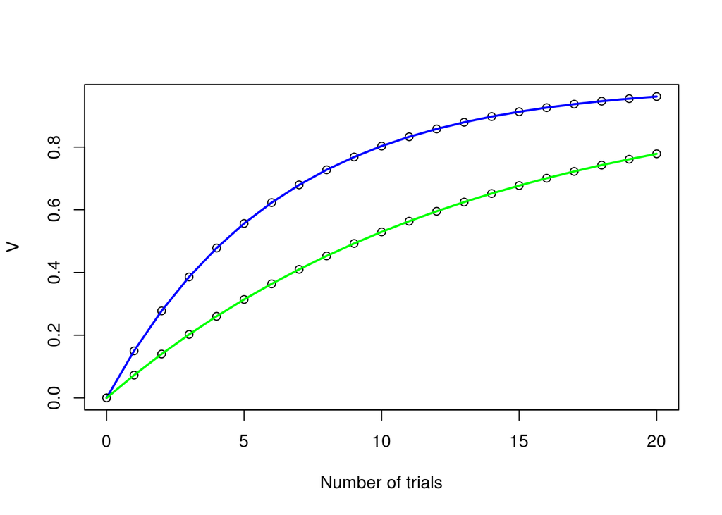

```r
latent_inhibition <- function(alpha_start, trials, inhibition_rate){
  new_alpha = alpha_start * inhibition_rate ^ trials
  return (new_alpha)
}

alpha1 = 0.15
alpha2 = 0.15

inhibition_trials = 10
inhibition_rate = 0.93
num_trials = 20
v_start = 0
v_max = 1.0

alpha1 = latent_inhibition(alpha1, inhibition_trials, inhibition_rate)
data = rescorla(v_start, v_max, alpha2, num_trials)
data_inhibited = rescorla(v_start, v_max, alpha1, num_trials)

plot(seq(v_start, num_trials), data$v, xlab = "Number of trials", ylab = "V")
lines(seq(from=v_start, to=num_trials), data$v,col="blue",lwd=2)
points(seq(from=v_start, to=num_trials), data_inhibited$v,col="black")
lines(seq(from=v_start, to=num_trials), data_inhibited$v,col="green",lwd=2)
```